# CPBS 7630 Module 2 - Feature Selection

February 16, 2016

#### Contents:

- Getting and cleaning data
- Feature selection - filtering methods
- Feature selection - wrapper methods
- Evaluation

### Getting and cleaning data

Get the drug sensitivity data from [Costello, et al. A Community Effort to Assess and Improve Drug Sensitivity Prediction Algorithms (2014)](http://www.nature.com/nbt/journal/v32/n12/full/nbt.2877.html).

```r
library(synapseClient)
synapseLogin(username = 'james.costello', password = 'cpbs7630')

# --------------------------- EXPRESSION DATA ---------------------------------

# Get gene expression data from the DREAM7 challenge
# (36,953 genes, 46 cell lines)
DREAM7.expression.data <- synGet('syn2785861')
local.file.path <- DREAM7.expression.data@filePath
expression.data <- read.delim(local.file.path,
                              header = T,
                              stringsAsFactors = F,
                              check.names = F)

# Store gene names for later, remove non-numeric data
genes <- expression.data$HGNC_ID
expression.data$Ensembl_ID <- NULL
expression.data$HGNC_ID <- NULL

# Transform into matrix of samples (cell lines) by features
expression.data <- t(expression.data)
colnames(expression.data) <- genes

# Check for NA values
# sum(is.na(expression.data))

# Log transform
expression.data <- log2(expression.data+1)

# Get rid of a duplicated gene name
expression.data <- expression.data[, !duplicated(colnames(expression.data))]

# ----------------------------- RESPONSE DATA ---------------------------------

# Get the drug response data from Synpase, training and test sets
DREAM7.train <- synGet('syn2785850')
train.data <- read.table(getFileLocation(DREAM7.train),
                         header = T,
                         sep='\t',
                         row.names = 1,
                         stringsAsFactors = F)

DREAM7.test <- synGet('syn2785837')
test.data <- read.table(getFileLocation(DREAM7.test),
                        header = T,
                        sep='\t',
                        row.names = 1,
                        stringsAsFactors = F)

# Concatenate the drug response data for train and test set (53 cell lines, 31 drugs)
response.data <- rbind(test.data,train.data)

# Pull out data on one drug (Drug 7) to use for regression/classification exercises
drug7.response <- response.data$Drug7
names(drug7.response) <- row.names(response.data)
drug7.response <- na.omit(drug7.response)

# Keep data for the 39 cell lines with both expression and Drug7 response data
celllines.in.both <- intersect(names(drug7.response), row.names(expression.data))
drug7.response <- drug7.response[names(drug7.response) %in% celllines.in.both]
expression.data <- expression.data[row.names(expression.data) %in% celllines.in.both,]
```

### Feature selection - filtering methods

#### Example 1 - filtering by average expression

We can begin by filtering out genes that are not expressed in our cell lines. How could we determine an optimal cutoff for defining “not expressed?”

```r
# Summarize average gene expression values - lots of genes with 0 expression
avg.exps <- colMeans(expression.data)
summary(avg.exps)
```

```
##     Min.  1st Qu.   Median     Mean  3rd Qu.     Max.
##  0.00000  0.05028  1.02500  2.72500  5.40300 16.43000
```

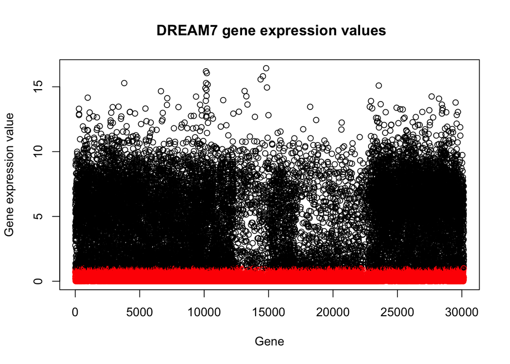

```r
# We can filter out genes that "aren't expressed" - how do we determine this?
cutoff <- 1
plot(avg.exps,
     main = ' DREAM7 gene expression values',
     xlab = 'Gene', ylab = 'Gene expression value',
     col = ifelse(avg.exps < cutoff, 'red', 'black'))
```

```r
expression.data <- expression.data[, avg.exps > cutoff]
# 14,996 genes have average expression value above the cutoff
# Are there any other cutoffs you might want to use?
```

#### Example 2 - filtering by variance

The most informative genes might be the ones with the most variability in their expression, so we can filter out genes with a low coefficient of variation.

```r
# Keep 5,000 genes with highest coefficient of variation
CV <- function(vec){
  return(sd(vec)/mean(vec))
}

# Order the 14,996 genes by their c.v. (highest to lowest) and keep top 5,000
all.genes = colnames(expression.data)
top.cv.genes <- all.genes[order(apply(expression.data, 2, CV), decreasing = T)][1:5000]
expression.data <- expression.data[, top.cv.genes]
```

Our final feature matrix consists of 39 cell lines and 5,000 genes, which is a very manageable size.

#### Example 3 - filtering by Information Gain

The first two examples filtered genes based on characteristics of the genes themselves, filtering on Information Gain takes the response values into account, that is, we can now look at how well the genes relate to drug response.

```r
# building from the expression.data that has already been filtered for average expression and CV, rank and select the top genes according to information gain.

library(FSelector)

# Information Gain must be calculated over discritized data as we will discuss

expression.discrete <- matrix(0, nrow=dim(expression.data)[1], ncol=dim(expression.data)[2])
colnames(expression.discrete) <- colnames(expression.data)
row.names(expression.discrete) <- row.names(expression.data)
for(i in 1:dim(expression.data)[2]) {
  s <- summary(expression.data[,i])
  expression.discrete[,i] <- .bincode(expression.data[,i], c(-Inf,s[2],s[3], s[5], Inf))
}

drug7.binary <- drug7.response > median(drug7.response)
drug7.binary[drug7.binary==F] <- "resistant"
drug7.binary[drug7.binary==T] <- "sensitive"
combined.data <- data.frame(cbind(expression.discrete, Response = drug7.binary))
genes.ig <- information.gain(Response~., combined.data)
expression.data.ig <- expression.data[,order(genes.ig, decreasing=T)]
```

### Feature selection - wrapper methods

Unlike filtering methods, wrapper methods for feature selection interact with the classifier. Again, refer to [Saeyes et al.](http://bioinformatics.oxfordjournals.org/content/23/19/2507.full.pdf+html) and [Bolon-Canedo et al.](http://www.sciencedirect.com/science/article/pii/S0020025514006021) for more information. For the example, we will see a wrapper-based method as implemented in the `FSelector` R package. More information on the algorithms in `FSelector` can be found [here](https://en.wikibooks.org/wiki/Data_Mining_Algorithms_In_R/Dimensionality_Reduction/Feature_Selection) or in the package [vignette](https://cran.r-project.org/web/packages/FSelector/FSelector.pdf).

#### Example 1 - forward selection

```r
# Use 10 random features to demonstrate forward search feature selection
set.seed(777)
expression.data.10 <- expression.data[, top.cv.genes[runif(10, 1, 5000)]]

# Combine expression data and response vector
combined.data <- data.frame(cbind(expression.data.10, Response = drug7.response))

library(FSelector)

# Mean squared error
MSE <- function(yhat, y){
    squared.error <- sum(mapply(function(yhat,y) (yhat-y)^2, yhat, y))
    return(squared.error/length(yhat))
}

evaluator <- function(subset.to.evaluate) {
  #k-fold cross validation
  k <- 5
  splits <- runif(nrow(combined.data))
  results = sapply(1:k, function(i) {
    test.idx <- (splits >= (i - 1) / k) & (splits < i / k)
    train.idx <- !test.idx
    test <- combined.data[test.idx,]
    train <- combined.data[train.idx,]
    lm.fit <- lm(Response ~ ., train)
    error = MSE(predict(lm.fit, test, type="response"), test$Response)
    return(-1*error)
  })
  print(subset.to.evaluate)
  print(mean(results))
  return(mean(results))
}

subset.to.use <- forward.search(colnames(combined.data)[-11], evaluator)
f <- as.simple.formula(subset.to.use, "Response")
```

#### Example 2 - recursive feature elimination (backward selection)

In the `caret` package, the `rfe()` function performs recursive feature elimination (RFE). The algorithm can be found [here](http://topepo.github.io/caret/rfe.html).

```r
library(caret)
library(randomForest)

# Use 10 random features to demonstrate RFE
set.seed(888)
x <- expression.data[, top.cv.genes[runif(10, 1, ncol(expression.data))]]
y <- drug7.response

# Standard caret preprocessing and scaling
norm.x <- preProcess(x)
x <- predict(norm.x, x)
x <- as.data.frame(x)

# Fit models with varying feature subset sizes
subsets <- c(1:5, 10, 15, 20)

# Create control object with cross-validation
ctrl <- rfeControl(functions = lmFuncs,
                   method = "repeatedcv",
                   repeats = 5,
                   verbose = FALSE)

# Fit linear model
lmProfile <- rfe(x, y,
                 sizes = subsets,
                 rfeControl = ctrl)

# View info, including top predictors
lmProfile
```

```
##
## Recursive feature selection
##
## Outer resampling method: Cross-Validated (10 fold, repeated 5 times)
##
## Resampling performance over subset size:
##
##  Variables   RMSE Rsquared RMSESD RsquaredSD Selected
##          1 1.1454   0.2353 0.2084     0.2837
##          2 0.9558   0.4678 0.3142     0.3419        *
##          3 1.0381   0.4182 0.3651     0.3278
##          4 1.0732   0.4098 0.4260     0.3389
##          5 1.1078   0.3781 0.4670     0.3411
##         10 1.2193   0.3598 0.5076     0.3379
##
## The top 2 variables (out of 2):
##    MUC2, ZNF502
```

```r
# Get string of variable names that were picked in the final model
predictors(lmProfile)
```

```
## [1] "MUC2"   "ZNF502"
```

```r
# View coefficients
lmProfile$fit
```

```
##
## Call:
## lm(formula = y ~ ., data = tmp)
##
## Coefficients:
## (Intercept)         MUC2       ZNF502
##      5.4360      -0.4669      -0.5471
```

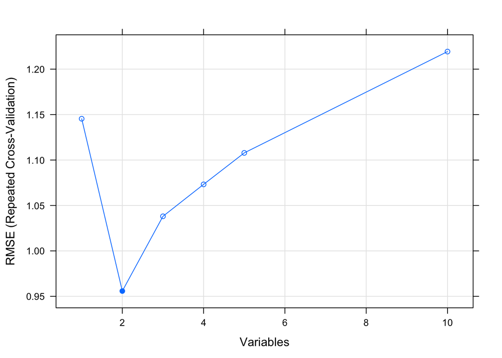

```r
# Plot
plot(lmProfile, type = c("g", "o"))
```

#### TODO #1: Implement a wrapper method for feature selection

The examples above use functions in the `FSelector` and `caret` packages to perform feature selection. What are the downsides of these methods? Are they guaranteed to find the optimal combination of features? Why or why not?

Implement your own wrapper method for feature selection (your method should be able to replace the `forward.search()` or `rfe` function in the example above).

### Evaluation

#### TODO #2: Evaluate feature selection methods

1. Implement your own version of an R function for Information Gain. You cannot use existing implementations of Information Gain, Mutual Information, Entropy, etc. Your function should return the meausure of Information Gain givne two vectors of values. In your Rmd script, add an example and describe how you are calculating Information Gain.
2. Implement a new way of evaluating features in your wrapper method. Plot your results comparing the performance of various subsets of features.
3. Find a different dataset related to your research interests to use in place of the DREAM7 drug sensitivity data. You will use this dataset throughout the course and for your presentations, you will discuss the results from your dataset instead of the DREAM7 drug sensitivity gene expression data.